# Next Text Prediction App

G. Hirang

[Try the App!](https://irishcreamlatte.shinyapps.io/NextText/)

Coursera Data Science Capstone

### INTRODUCTION

Technological advances made it easy to collect vast amounts of data, including textual information:

- blogs and personal writings
- Tweets, Facebook and other social media posts
- news, scientific and other types of articles

Natural Language Processing (NLP) allows us to process these data in order to use them [for other purposes](https://monkeylearn.com/blog/definitive-guide-natural-language-processing/):

- Machine Translation
- Sentiment Analysis
- Automatic Classification
- Text Classification
- Text Prediction

### NEXT TEXT APP

A simple text prediction app based on the [Kneser-Ney algorithm](https://web.stanford.edu/%7Ejurafsky/slp3/3.pdf):

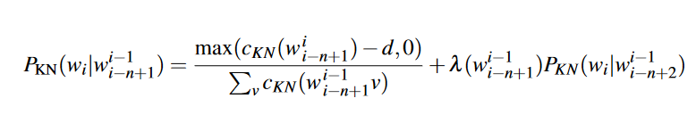

The algorithm predicts the next word based on probabilities estimated using trigrams and bigrams. Instead of just looking at how frequently used a word is (i.e. in unigrams), it considers the context of word use:

- How many bigrams or trigrams does it complete?

### NEXT TEXT APP

2 words entered:

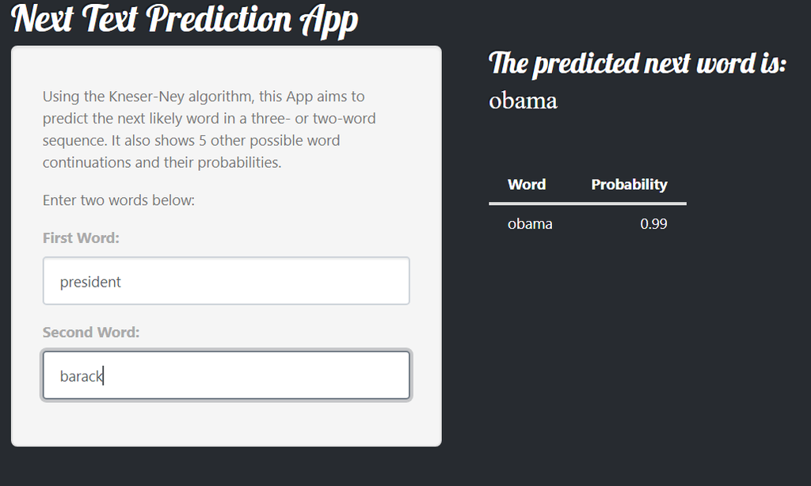

- With a trigram match: use trigram probabilities.
- No trigram match: use bigram probabilities.

1 word entered:

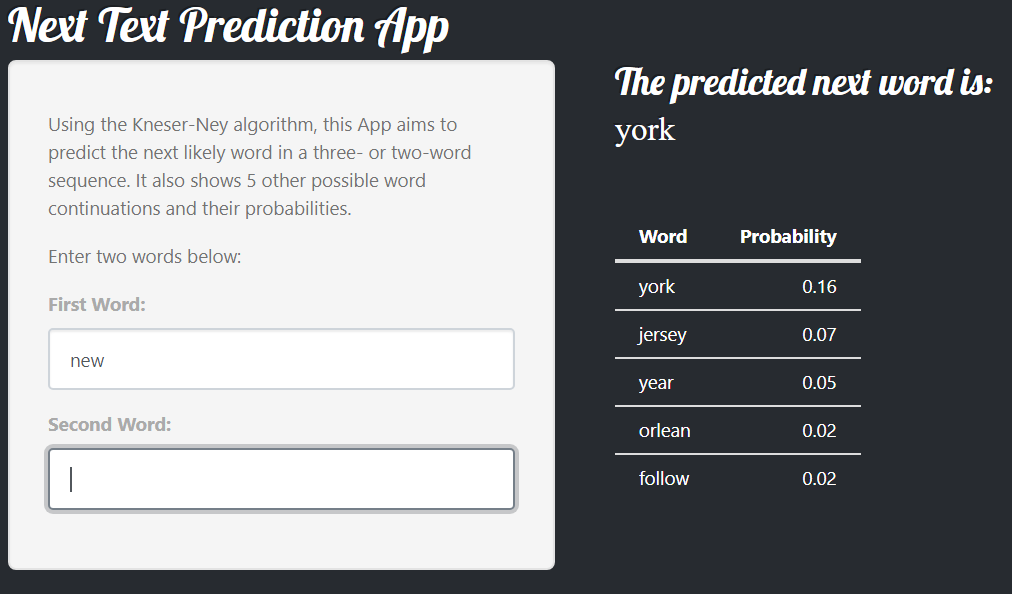

- No bigram match: use unigram probabilities.
- No words entered: use random frequently used word.

### REFERENCES

Daniel Jurafsky & James H. Martin. [N-gram Language Models.](https://web.stanford.edu/%7Ejurafsky/slp3/3.pdf)

Denny Ceccon. [A simple numerical example for Kneser-Ney Smoothing[NLP].](https://medium.com/@dennyc/a-simple-numerical-example-for-kneser-ney-smoothing-nlp-4600addf38b8)

Frankie James. [Modified Kneser-Ney Smoothing of n-gram Models.](https://core.ac.uk/download/pdf/22877567.pdf)

Javier Couto. [The Definitive Guide to Natural Language Processing.](https://monkeylearn.com/blog/definitive-guide-natural-language-processing/)

Jon Gauthier. [Kneser-Ney smoothing explained.](http://www.foldl.me/2014/kneser-ney-smoothing/) Mittul Singh. [N-gram Language models and Smoothing.](https://jon.dehdari.org/teaching/uds/lt1/ngram_lms.pdf)